# Board Games markedDown

### **Analysis**

In this section we will build some plots using `ggplot2()`

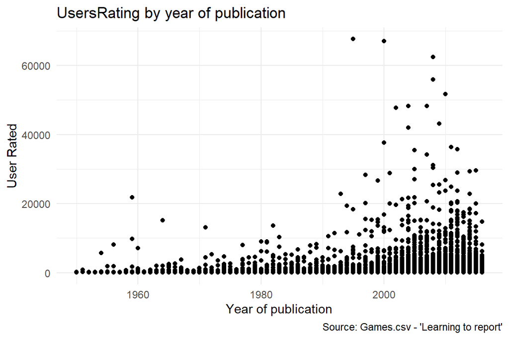

And lets build a table that summarize numerical values.

```r
kable(summary(numerical.board.games))
```

|  | compilation | max_players | max_playtime | min_age | min_players | min_playtime | playing_time | year_published | average_rating | users_rated |
| --- | --- | --- | --- | --- | --- | --- | --- | --- | --- | --- |
|  | Length:10532 | Min. : 0.000 | Min. : 0.00 | Min. : 0.000 | Min. :0.000 | Min. : 0.00 | Min. : 0.00 | Min. :1950 | Min. :1.384 | Min. : 50.0 |
|  | Class :character | 1st Qu.: 4.000 | 1st Qu.: 30.00 | 1st Qu.: 8.000 | 1st Qu.:2.000 | 1st Qu.: 25.00 | 1st Qu.: 30.00 | 1st Qu.:1998 | 1st Qu.:5.830 | 1st Qu.: 85.0 |
|  | Mode :character | Median : 4.000 | Median : 45.00 | Median :10.000 | Median :2.000 | Median : 45.00 | Median : 45.00 | Median :2007 | Median :6.393 | Median : 176.0 |
|  | NA | Mean : 5.657 | Mean : 91.34 | Mean : 9.715 | Mean :2.071 | Mean : 80.88 | Mean : 91.34 | Mean :2003 | Mean :6.371 | Mean : 870.1 |
|  | NA | 3rd Qu.: 6.000 | 3rd Qu.: 90.00 | 3rd Qu.:12.000 | 3rd Qu.:2.000 | 3rd Qu.: 90.00 | 3rd Qu.: 90.00 | 3rd Qu.:2012 | 3rd Qu.:6.943 | 3rd Qu.: 518.0 |
|  | NA | Max. :999.000 | Max. :60000.00 | Max. :42.000 | Max. :9.000 | Max. :60000.00 | Max. :60000.00 | Max. :2016 | Max. :9.004 | Max. :67655.0 |

## Tables

### kable: for basic tables

The `kable` command is a fast way to create tables. Here is the simple output of R without using any commands:

```r
tab <- head(diamonds[, 1:7])
tab
```

```
## # A tibble: 6 × 7
##   carat cut       color clarity depth table price
##   <dbl> <ord>     <ord> <ord>   <dbl> <dbl> <int>
## 1  0.23 Ideal     E     SI2      61.5    55   326
## 2  0.21 Premium   E     SI1      59.8    61   326
## 3  0.23 Good      E     VS1      56.9    65   327
## 4  0.29 Premium   I     VS2      62.4    58   334
## 5  0.31 Good      J     SI2      63.3    58   335
## 6  0.24 Very Good J     VVS2     62.8    57   336
```

Now using `kable`:

```r
kable(tab)
```

| carat | cut | color | clarity | depth | table | price |
| --- | --- | --- | --- | --- | --- | --- |
| 0.23 | Ideal | E | SI2 | 61.5 | 55 | 326 |
| 0.21 | Premium | E | SI1 | 59.8 | 61 | 326 |
| 0.23 | Good | E | VS1 | 56.9 | 65 | 327 |
| 0.29 | Premium | I | VS2 | 62.4 | 58 | 334 |
| 0.31 | Good | J | SI2 | 63.3 | 58 | 335 |
| 0.24 | Very Good | J | VVS2 | 62.8 | 57 | 336 |

The `kable` command has arguments for altering how the table looks, including changing the column names, alignment, captions, rounding, and more.

```r
better.colnames <- c("Carat", "Cut", "Colour", "Clarity", "Depth(%)", "Relative width", "Price($)")
better.tab <- kable(tab,
      col.names = better.colnames,
      align = c("rcccrrr"),
      caption = "My sensible caption")
better.tab
```

My sensible caption

| Carat | Cut | Colour | Clarity | Depth(%) | Relative width | Price($) |
| --- | --- | --- | --- | --- | --- | --- |
| 0.23 | Ideal | E | SI2 | 61.5 | 55 | 326 |
| 0.21 | Premium | E | SI1 | 59.8 | 61 | 326 |
| 0.23 | Good | E | VS1 | 56.9 | 65 | 327 |
| 0.29 | Premium | I | VS2 | 62.4 | 58 | 334 |
| 0.31 | Good | J | SI2 | 63.3 | 58 | 335 |
| 0.24 | Very Good | J | VVS2 | 62.8 | 57 | 336 |

More details on `kable` here: https://bookdown.org/yihui/rmarkdown-cookbook/kable.html

# **References**

Lukman, L., W. Wahyudin, Didi Suryadi, Dadan Dasari, and Sufyani Prabawanto. 2022. “Mental Action Way of Understanding (WoU) and Way of Thinking (WoT) Students in Statistics Learning in Higher Education.” *International Journal on Advanced Science, Engineering and Information Technology* 12 (6): 2428–37. https://doi.org/10.18517/ijaseit.12.6.17052.